# Word Frequency

### Introduction

The total number of words and the number of distinct words (often referred to as ‘tokens’ or ‘terms’) can be helpful in exploring the content and trends within a corpus. Word frequencies are visualized to understand contributions of terms across and within documents. Typically, stop words such as “the”, “and” or “a” are removed from the corpus when calcualting word frequencies.  
All visualizations on this page use the preprocessed and cleaned version of the corpus.

### Word Counts (number of times the word appears across all documents)

Word clouds provide an often aesthetically pleasing visual summary of the most prominent terms in a document or corpus as a whole. The bigger a word is, the more frequently it occurs in the entire corpus. Placement of specific words within the cloud is random and does not infer any relationship between terms.

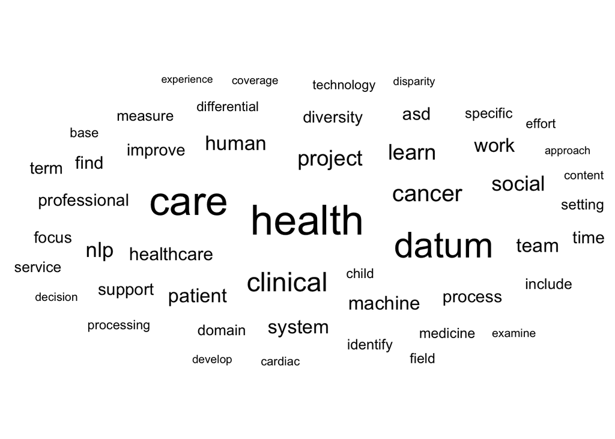

### Word Document Counts (number of document containing the word)

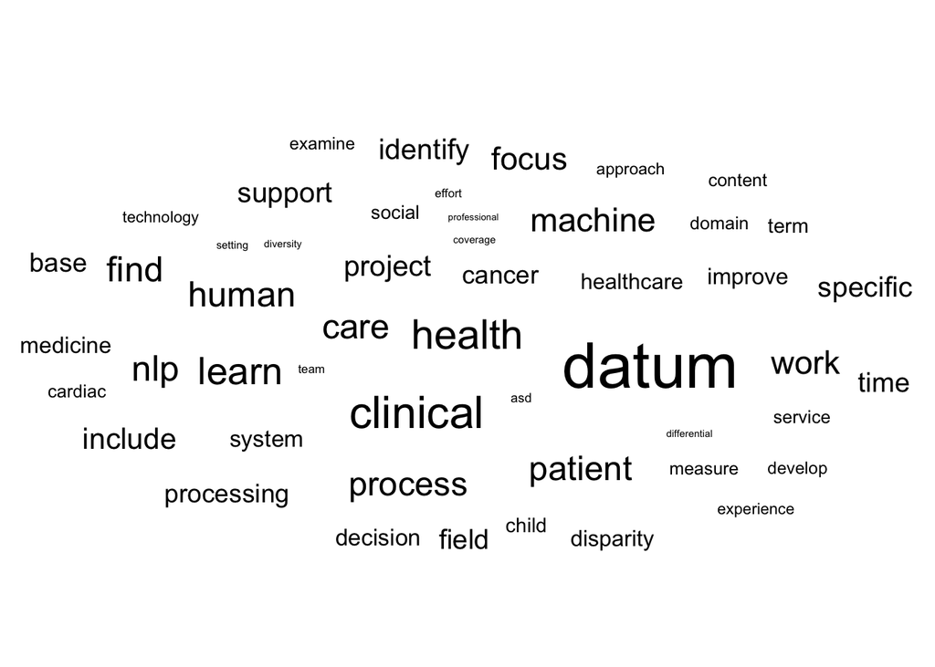

### Word Counts Table

This section provides a searchable and sortable table to explore distinct words and their relative frequencies. Word = distinct term. Frequency = number of times that word appeared across all the documents. Document_Count = number of documents that have at least one occurrence of that word. Relative_Freq = percentage of the corpus that is made up of that word. Relative_Document_Count = percentage of documents that contain the word at least once.

| Word | Frequency | Document_Count | Relative_Freq | Relative_Document_Count |
| --- | --- | --- | --- | --- |
| ability | 2 | 2 | 0.2203 | 8.6957 |
| abstract | 1 | 1 | 0.1101 | 4.3478 |
| academic | 1 | 1 | 0.1101 | 4.3478 |
| accelerate | 1 | 1 | 0.1101 | 4.3478 |
| access | 1 | 1 | 0.1101 | 4.3478 |
| accuracy | 1 | 1 | 0.1101 | 4.3478 |
| across | 1 | 1 | 0.1101 | 4.3478 |
| action | 1 | 1 | 0.1101 | 4.3478 |
| actual | 1 | 1 | 0.1101 | 4.3478 |
| acute | 1 | 1 | 0.1101 | 4.3478 |

[output cut: 556 more lines]

Created at the [UC Davis Data Lab](http://ds.lib.ucdavis.edu/)